# CellFindR Vignette for Seurat 4.0

Kevin Yu

2022-08-24

## Introduction

CellFindR is a pipeline for Single Cell RNA sequencing that helps with unsupervised clustering of your groups. It uses a few scripts built in R and utilizes the Seurat environment package: https://satijalab.org/seurat/.

This tutorial helps guide users to using the functions for CellFindR and walks through an analysis of one dataset. More information about the CellFindR algorithm can be found here in our preprint: https://www.biorxiv.org/content/10.1101/739680v2

## Step 1: initializing environment

The first step is to make sure R has all the packages needed: please install: Seurat, dplyr, stringr, ggplot2, RColorBrewer, pheatmap, limma and presto. We recommend running functions in RStudio. We are runninng R 4.2.1 with Seurat 4.0

```r
library(Seurat)
library(dplyr)
library(stringr)
library(ggplot2)
library(RColorBrewer)
library(pheatmap)
library(limma)
library(presto)
```

We can actually easily load our cellfindR functions by just running all the code in the separate CellFindR.R script file. All the functions then should be accessible in our environment. That file should start with the load_tenx fuction, when this is run, it should populate your data environment with these functions.

Step 2: Initializing dataset Please set your working environment appropriately: mine is set into the folder where the 10x files are located for easiest processing. We are calling these variable:

```r
file_loc = 'location of 10x files'
output_loc = 'location of where output files want to go'
```

```r
proj_name='m_145w_inner_ear'
```

In this exercise, we have placed in github (as well in GEO) our E14.5 dataset and we are running this exercise on that dataset for simplicity.

### loading the data

We will use our load_tenx function that will process the general initialization of seurat object You can also do this yourself as along as your have an Seurat object in your environment that you would like to run through CellFindR. Of note, we do not apply the 5% mitochondrial filter here.

```r
tenx <- load_tenx(file_loc=file_loc,output_loc=output_loc,proj_name=proj_name)
```

we can manually set a resolution for the first layer if the groups are clear, this step saves a bit of computational power since finding the resolution for the first layer is a bit computationally intensive. lets see what this first layer looks like!

```
## Modularity Optimizer version 1.3.0 by Ludo Waltman and Nees Jan van Eck
##
## Number of nodes: 10047
## Number of edges: 342021
##
## Running Louvain algorithm...
## Maximum modularity in 10 random starts: 0.8943
## Number of communities: 16
## Elapsed time: 0 seconds
```

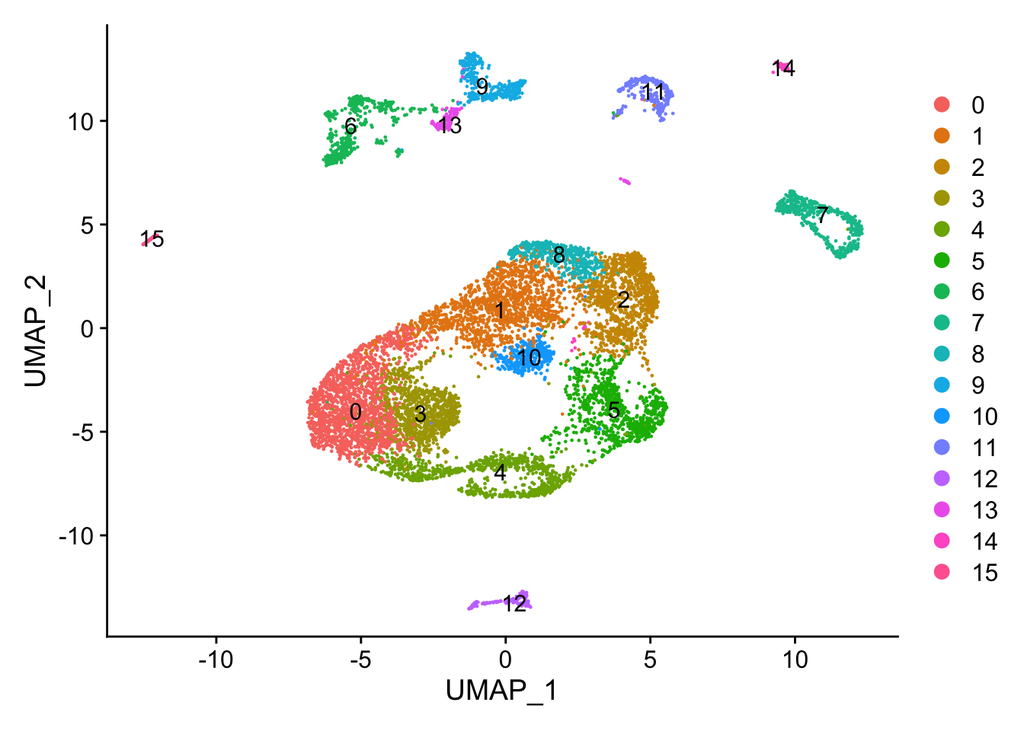

### how to use the find_res function

to use the find_res function, you just need to place the seurat object into the function

### you can then output these files with the out_tenx function

it runs the clustering and UMAP at the set resolution and then output the UMAP and RDS file for the Seurat object

```r
tenx <- out_tenx(tenx,output_loc=output_loc,res=res,proj_name=proj_name)
```

## Step 3: Running CellFindR

Once you have the seurat object with the initial clustering group set, the subclustering can be done via the subclustering function. This may take a few minutes to run! But files should start populating in the set directory In the directory, it should contain: + 1: create a folder for each cluster/subcluster + 2: inside each subcluster it should create a .csv file with the differential gene expression of the subgroups + 3: a UMAP showing the distribution of cells + 4: a seurat rds file of this subgroup + 5: A UMAP of the expression of the top differential genes + 6: A violin plot of the gene expression based on the subclusters

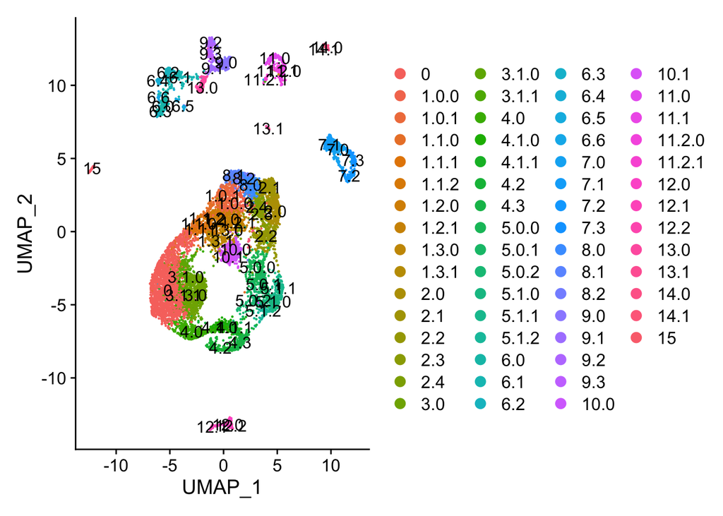

```r
tenx <- sub_clustering(tenx,output_folder=output_loc)
DimPlot(tenx, reduction = "umap",  label = TRUE)
```

## Step 4: Output data

Once CellFindR has finished running, we can obtain the final UMAP and and overall matrix by running the analysis tool: get_analysis as well as the stats file which shows the top genes for each subcluster as well as statistics regarding number of cells. The violin plots and cluster maps of the top genes can be outputted by the get_plots function

```r
write.csv(get_matrix(tenx),  file = paste(output_loc, '/', 'matrix_cellfindR.csv', sep = ''))
gen_matrix_plot(tenx,output_folder=output_loc,proj_name=proj_name)
get_plots(tenx,output_folder=output_loc)
#get_analysis(tenx,output_folder=output_loc)
```

This concludes the tutorial for running CellFindR, you should have a manipulable R object with the CellFindR groupings as well as the output folder with the above analyses.